# Multiple_Linear_Regression

# 다항 회귀분석

#### 미국의 50개주의 문맹률과 수입, 인구수, 결빙일, 살인사건 발생률에 관한 데이터를 분석하였다.

- 독립변수 : 문맹률, 수입, 인구수, 결빙일
- 종속변수 : 살인사건 발생률

# 다항회귀모형 진단

회귀 모형은 선형성,독립성,등분산성,비상관성,정상성의 가정을 만족시켜야한다.

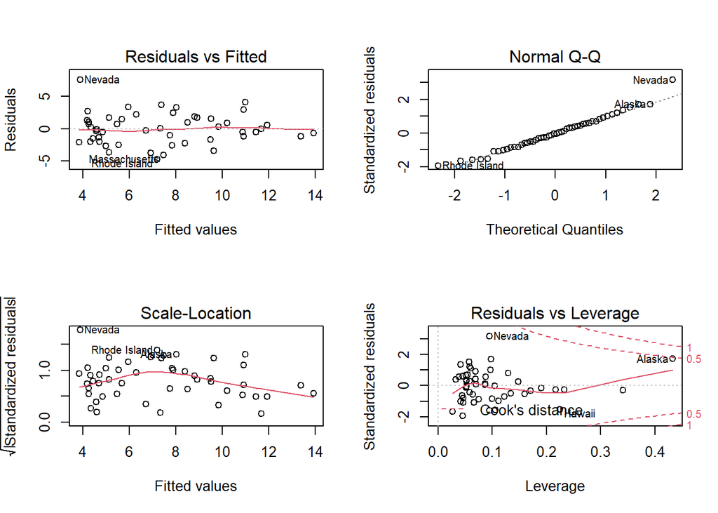

```r
states <- as.data.frame(state.x77[,c("Murder", "Population",
                                     "Illiteracy", "Income", "Frost")])
fit=lm(Murder~Population+Illiteracy+Income+Frost,data=states)
par(mfrow=c(2,2))
#한 화면에 여러 그래프를 넣고 싶을 때가 있습니다.
#이럴 때 사용하는 함수가 par 함수입니다.아래와 같은 형식으로 사용하시면 됩니다.
#par(mfrow = c(x축 방향으로 분할 수, y축 방향으로 분할 수))
#2x2로 분할

plot(fit)
```

```r
par(mfrow=c(1,1))
```

위의 그림에서 보는 것처럼 Q-Q plot에서 Nevada 주의 데이터가 이상치인 것을 제외하고 통계의 가정을 잘 만족시키는 것을 알 수 있다.

```r
library(car)
```

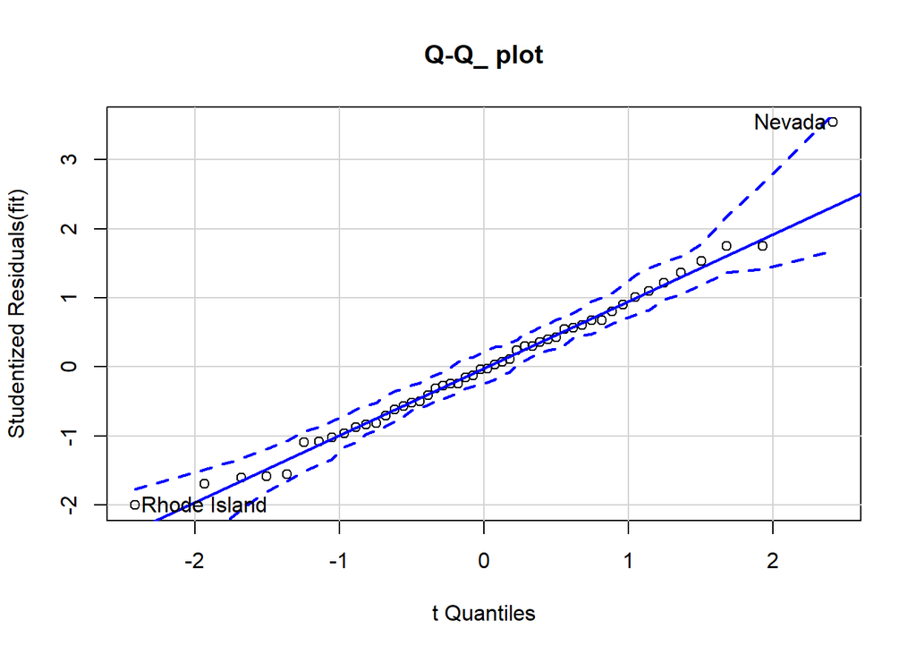

```
##       Nevada Rhode Island
##           28           39
```

```r
qqPlot(fit,labels=row.names(states),id.method="identify",simulate=TRUE,main="Q-Q_ plot")
```

위 그래프를 보면 Nevada 주를 제외하고 모든 점이 회귀선과 95% 신뢰구간 안에 위치해 있어 정규성 가정을 만족시킨다. 하지만 Nevada 주는 큰 잔차를 보인다.

```r
require(car)
vif(fit)
```

```
## Population Illiteracy     Income      Frost
##   1.245282   2.165848   1.345822   2.082547
```

```r
sqrt(vif(fit))>2
```

```
## Population Illiteracy     Income      Frost
##      FALSE      FALSE      FALSE      FALSE
```

다중공선성은 분산팽창지수(variation inflation factor, VIF)라는 통계량을 사용하여 계산할 수 있다. 한 예측변수에 대해 VIF의 제곱근은 다중공산성의 정도를 나타내주며 일반적으로 VIF−−−−√가 2 이상인 것은 다중공선성 문제가 있다는 것을 뜻한다. VIF값은 car 패키지의 vif() 함수로 계산할 수 있다. vif 함수로 fit 모형을 검사한 결과 다중공선성 문제는 없다는 것을 확인하였다.

# 최선의 회귀모형 고르기

변수를 선택해 회귀모형을 설정하는 다음 두 원칙을 따른다. 두 원칙은 서로 이율배반적이므로 타협이 이뤄져야 한다.(적절한 상황에 적절한 설명변수 선택 필요)

1. y에 영향을 미칠 수 있는 모든 설명변수 x들은 y의 값을 예측하는데 참여시킨다.
2. 설명변수 수가 많아지면 관리에 많은 노력이 요구되니 가능한 적은 범위 내에 적은 수의 설명변수를 포함시킨다.

### 모형의 비교- adjusted R2 이용

다중회귀분석에서 모형의 비교를 위해서는 anova() 함수를 쓴다. 이해를 돕기 위해 states 데이터를 예로 들어본다. Murder를 반응변수로 나머지 네 변수를 모두 예측변수로 넣고 회귀분석을 실시해본다.

```r
states <- as.data.frame(state.x77[,c("Murder", "Population",
                                 "Illiteracy", "Income", "Frost")])
fit1 <- lm(Murder ~ . ,data=states)
summary(fit1)
```

```
##
## Call:
## lm(formula = Murder ~ ., data = states)
##
## Residuals:
##     Min      1Q  Median      3Q     Max
## -4.7960 -1.6495 -0.0811  1.4815  7.6210
##
## Coefficients:
##              Estimate Std. Error t value Pr(>|t|)
## (Intercept) 1.235e+00  3.866e+00   0.319   0.7510
## Population  2.237e-04  9.052e-05   2.471   0.0173 *
## Illiteracy  4.143e+00  8.744e-01   4.738 2.19e-05 ***
## Income      6.442e-05  6.837e-04   0.094   0.9253
## Frost       5.813e-04  1.005e-02   0.058   0.9541
## ---
## Signif. codes:  0 '***' 0.001 '**' 0.01 '*' 0.05 '.' 0.1 ' ' 1
##
## Residual standard error: 2.535 on 45 degrees of freedom
## Multiple R-squared:  0.567,  Adjusted R-squared:  0.5285
## F-statistic: 14.73 on 4 and 45 DF,  p-value: 9.133e-08
```

*회귀모형의 설명력 R-Squared는 독립변수에 의해서 종속변수가 얼마만큼 설명되었는가를 나타내는 회귀모형의 설명력 0.567의 뜻은 살인사건 발생률에 대한 인구수, 문맹률, 수입, 결빙일의 설명력은 56.7%이며, 나머지 43.3%는 다른 변수에서 찾아야 한다.

*F-statistic: 14.73 on 4 and 45 DF, p-value: 9.133e-08 회귀 모형의 적합성을 나타내는 데, 위 검정 통계량을 이용해서 F값으로 회귀모형 자체를 신뢰할 수 있는지를 판단함 만약 0.05이상일 경우, 회귀선은 모형에 부적합하다는 뜻

결과에서 Income과 Frost의 p값이 각각 0.925, 0.954로 유의하지 않다. 두 변수를 제거하고 다시 회귀모형을 만든다.

```r
fit2 <- lm(Murder ~ Population + Illiteracy, data=states)
summary(fit2)
```

```
##
## Call:
## lm(formula = Murder ~ Population + Illiteracy, data = states)
##
## Residuals:
##     Min      1Q  Median      3Q     Max
## -4.7652 -1.6561 -0.0898  1.4570  7.6758
##
## Coefficients:
##              Estimate Std. Error t value Pr(>|t|)
## (Intercept) 1.652e+00  8.101e-01   2.039  0.04713 *
## Population  2.242e-04  7.984e-05   2.808  0.00724 **
## Illiteracy  4.081e+00  5.848e-01   6.978 8.83e-09 ***
## ---
## Signif. codes:  0 '***' 0.001 '**' 0.01 '*' 0.05 '.' 0.1 ' ' 1
##
## Residual standard error: 2.481 on 47 degrees of freedom
## Multiple R-squared:  0.5668, Adjusted R-squared:  0.5484
## F-statistic: 30.75 on 2 and 47 DF,  p-value: 2.893e-09
```

fit2 모형에서는 Population과 Illiteracy 두 변수 모두 유의하게 나왔다. 두 개의 모형을 anova()로 비교해보자.

```r
anova(fit2, fit1)
```

```
## Analysis of Variance Table
##
## Model 1: Murder ~ Population + Illiteracy
## Model 2: Murder ~ Population + Illiteracy + Income + Frost
##   Res.Df    RSS Df Sum of Sq      F Pr(>F)
## 1     47 289.25
## 2     45 289.17  2  0.078505 0.0061 0.9939
```

두 모형을 비교한 F test에서 p값이 0.9939로 유의하지 않으므로 fit1에서 두 변수를 제거하는 것은 정당하다.

### 모형의 비교 - AIC 를 이용

AIC 값이 적은 모형, 즉 적은 인수를 가지고 적절한 적합성을 보이는 모형이 선호된다.

```r
AIC(fit1,fit2)
```

```
##      df      AIC
## fit1  6 241.6429
## fit2  4 237.6565
```

AIC 값 또한 fit1에 비해 fit2가 좋은 모형이라는 것을 알려주고 있다.

### 다중회귀모형에서 변수의 선택

step() 함수는 AIC 값을 이용하여 단계적 회귀를 수행하는 함수로 forward, backward stepwise regression을 모두 할 수 있다.

- Backward Regression Backward regression은 가능한 많은 변수에서 시작해 하나씩 제거하는 방법이다. 먼저 가능한 많은 변수들을 포함하는 full.model을 만들고 의미 없는 변수들을 제거하기 위해 step 함수를 사용한다. 그리고 그 결과를 reduced.model에 저장한다.

```r
full.model=lm(Murder~.,data=states)
reduced.model=step(full.model,direction="backward")
```

```
## Start:  AIC=97.75
## Murder ~ Population + Illiteracy + Income + Frost
##
##              Df Sum of Sq    RSS     AIC
## - Frost       1     0.021 289.19  95.753
## - Income      1     0.057 289.22  95.759
## <none>                    289.17  97.749
## - Population  1    39.238 328.41 102.111
## - Illiteracy  1   144.264 433.43 115.986
##
## Step:  AIC=95.75
## Murder ~ Population + Illiteracy + Income
##
##              Df Sum of Sq    RSS     AIC
## - Income      1     0.057 289.25  93.763
## <none>                    289.19  95.753
## - Population  1    43.658 332.85 100.783
## - Illiteracy  1   236.196 525.38 123.605
##
## Step:  AIC=93.76
## Murder ~ Population + Illiteracy
##
##              Df Sum of Sq    RSS     AIC
## <none>                    289.25  93.763
## - Population  1    48.517 337.76  99.516
## - Illiteracy  1   299.646 588.89 127.311
```

최종선택된 모형은 다음과 같다.

```r
summary(reduced.model)
```

```
##
## Call:
## lm(formula = Murder ~ Population + Illiteracy, data = states)
##
## Residuals:
##     Min      1Q  Median      3Q     Max
## -4.7652 -1.6561 -0.0898  1.4570  7.6758
##
## Coefficients:
##              Estimate Std. Error t value Pr(>|t|)
## (Intercept) 1.652e+00  8.101e-01   2.039  0.04713 *
## Population  2.242e-04  7.984e-05   2.808  0.00724 **
## Illiteracy  4.081e+00  5.848e-01   6.978 8.83e-09 ***
## ---
## Signif. codes:  0 '***' 0.001 '**' 0.01 '*' 0.05 '.' 0.1 ' ' 1
##
## Residual standard error: 2.481 on 47 degrees of freedom
## Multiple R-squared:  0.5668, Adjusted R-squared:  0.5484
## F-statistic: 30.75 on 2 and 47 DF,  p-value: 2.893e-09
```

- Forward Regression Forward regression은 적은 수의 변수에서 시작해 변수를 하나씩 추가하는 방법이다.

```r
min.model=lm(Murder~1,data=states)
fwd.model=step(min.model,direction="forward",
               scope=(Murder~Population+Illiteracy+Income+Frost),trace=0)
summary(fwd.model)
```

```
##
## Call:
## lm(formula = Murder ~ Illiteracy + Population, data = states)
##
## Residuals:
##     Min      1Q  Median      3Q     Max
## -4.7652 -1.6561 -0.0898  1.4570  7.6758
##
## Coefficients:
##              Estimate Std. Error t value Pr(>|t|)
## (Intercept) 1.652e+00  8.101e-01   2.039  0.04713 *
## Illiteracy  4.081e+00  5.848e-01   6.978 8.83e-09 ***
## Population  2.242e-04  7.984e-05   2.808  0.00724 **
## ---
## Signif. codes:  0 '***' 0.001 '**' 0.01 '*' 0.05 '.' 0.1 ' ' 1
##
## Residual standard error: 2.481 on 47 degrees of freedom
## Multiple R-squared:  0.5668, Adjusted R-squared:  0.5484
## F-statistic: 30.75 on 2 and 47 DF,  p-value: 2.893e-09
```

Forward selection에서도 같은 결과를 얻었다.

# 상대적 중요성

```r
states <- as.data.frame(state.x77[,c("Murder", "Population",
                                 "Illiteracy", "Income", "Frost")])
zstates <- as.data.frame(scale(states))
zfit <- lm(Murder~Population + Income + Illiteracy + Frost, data=zstates)
coef(zfit)
```

```
##   (Intercept)    Population        Income    Illiteracy         Frost
## -2.054026e-16  2.705095e-01  1.072372e-02  6.840496e-01  8.185407e-03
```

결과를 보면 문맹률(Illiteracy)이 표준편차만큼 증가하면 인구수, 수입, 기온이 일정할 때 살인사건 발생률이 표준편차의 0.68배 증가하는 것을 알 수 있다. 표준화된 회귀계수를 사용하면 문맹률이 가장 중요한 예측인자이고 Frost가 가장 중요도가 떨어진다.

```r
relweights <- function(fit,...){
         R <- cor(fit$model)
         nvar <- ncol(R)
         rxx <- R[2:nvar, 2:nvar]
         rxy <- R[2:nvar, 1]
         svd <- eigen(rxx)
         evec <- svd$vectors
         ev <- svd$values
         delta <- diag(sqrt(ev))
         lambda <- evec %*% delta %*% t(evec)
         lambdasq <- lambda ^ 2
         beta <- solve(lambda) %*% rxy
         rsquare <- colSums(beta ^ 2)
         rawwgt <- lambdasq %*% beta ^ 2
         import <- (rawwgt / rsquare) * 100
         import <- as.data.frame(import)
         row.names(import) <- names(fit$model[2:nvar])
         names(import) <- "Weights"
         import <- import[order(import),1, drop=FALSE]
         dotchart(import$Weights, labels=row.names(import),
            xlab="% of R-Square", pch=19,
            main="Relative Importance of Predictor Variables",
            sub=paste("Total R-Square=", round(rsquare, digits=3)),
            ...)
         return(import)
}
```

실제 예로써 states데이터의 예측변수들의 상대적 중요도를 보는 방법은 다음과 같다.

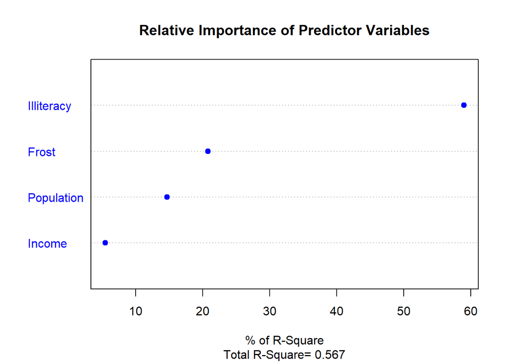

```
##              Weights
## Income      5.488962
## Population 14.723401
## Frost      20.787442
## Illiteracy 59.000195
```

```r
states <- as.data.frame(state.x77[,c("Murder", "Population",
                "Illiteracy", "Income", "Frost")])
fit <- lm(Murder ~ Population + Illiteracy + Income + Frost, data=states)
relweights(fit, col="blue")
```